# Final Processing

```python
import pandas as pd
import json
import seaborn as sns
import matplotlib.pyplot as plt
from sklearn.preprocessing import MinMaxScaler
```

```python
myanimelist = pd.read_csv('myanimelist/myanimelist_details_processed.csv')
```

```python
anlist = pd.read_csv('anilist/anlist_data.csv')
```

```python
balkom = pd.read_csv('balkom/balkom_processed.csv')
```

# Joining data

```python
df = myanimelist.merge(anlist, how='inner', left_on='id', right_on='mal_id').reset_index(drop=True)
```

```python
df = df.drop('mal_id',axis=1)
```

```python
df.isna().sum()
```

```
id                      0
name                    0
sup_name             2401
poster                274
Synonyms             2033
Japanese                3
English              1539
Spanish              4332
German               4257
French               4147
Type                    0
Episodes                0
Status                  0
Aired                   0
Producers            1321
Licensors            2611
Studios               110
Source                  0
Genres                105
Themes               1495
Demographic          3559
Duration                0
Rating                  7
Score                   6
Ranked                 32
Popularity              0
Members                 0
Favorites               0
Premiered            2852
number_of_votes         0
number_of_members       0
Synopsis                0
Related_Anime         483
review_ratio_box        0
Broadcast            2852
anidb_id              133
data                    0
dtype: int64
```

```python
new_columns_names = {
    'data':'anilist_data',
}
df = df.rename(columns=new_columns_names)
```

# Translitraion

```python
english_to_arabic = {
    "aa": "a",
    "bb": "b",
    "cc": "c",
    "dd": "d",
    "ee": "e",
    "ff": "f",
    "gg": "g",
    "hh": "h",
    "ii": "i",
    "jj": "j",
    "kk": "k",
    "ll": "l",
    "mm": "m",
    "nn": "n",
    "oo": "o",
    "pp": "p",
    "qq": "q",
    "rr": "r",
    "ss": "s",
    "tt": "t",
    "uu": "u",
    "vv": "v",
    "ww": "w",
    "xx": "x",
    "yy": "y",
    "zz": "z",


    "butt":"بت",


    "zha": "ژا",
    "ths": "ص",
    "xin":"شين",
    "fly":"فلاي",


    "sh": "ش",
    "ch": "تش",
    "th": "ث",
    "ea": "ي",
    "gh": "غ",
    "kh": "خ",
    "th": "ث",
    "dh": "ذ",
    "ay": "اي",
    "ou": "و",
    "dx":"دي أس",
    "cy":"سي",
    "ll":"ل",
    "eo":"ي",
    "ck":"ك",
    "ke":"كي",
    "ru":"رو",
    "oa":"و",


    "a": "ا",
    "e": "ي",
    "i": "ي",
    "o": "و",
    "u": "ي",
    "b": "ب",
    "p": "ب",
    "t": "ت",
    "d": "د",
    "j": "ج",
    "f": "ف",
    "v": "ف",
    "k": "ك",
    "g": "ج",
    "h": "ه",
    "l": "ل",
    "m": "م",
    "n": "ن",
    "r": "ر",
    "w": "و",
    "y": "ي",
    "s": "س",
    "q": "ق",
    "c": "ك",
    "z": "ز",
    " ": " ",
    "-": "-",
    ".": ".",
    "`": "ع",
    "x": "كس",
    "'": "'",
    "@": "at",
}

single_word = { "a": "أ","b": "بي","c": "سي","d": "دي","e": "إ","f": "أف","g": "جي","h": "أتش","i": "أي","j": "جي","k": "ك","l": "آل","m": "أم","n": "إن","o": "أو","p": "بي", "q": "كيو","r": "أر", "s": "أس","t": "تي","u": "يو","v": "في","w": "دبليو","x": "إكس","y": "واي","z": "زيد", "1": "1", "2": "2", "3": "3", "4": "4", "5": "5", "6": "6", "7": "7", "8": "8", "9": "9", "0": "0",
}
def translitraion(english_word):
    try:
        words_parts = english_word.lower().split()
    except:
        return None
    output = []

    for word in words_parts:


        try:
            if len(word) == 1:
                word = single_word[word]
        except:
            pass
        try:
            if word[0] == 'i':
                word= 'إي' + word[1:]
            if word[0] == 'e':
                word= 'إي' + word[1:]
            if word[0] == 'o':
                word= 'أو' + word[1:]
            if word[0] == 'u':
                word= 'يو' + word[1:]
            if word[0] == 'x':
                word= 'ز' + word[1:]

        except:
            pass
        if len(word)>2 and word[-1] == 'e' and word[-2] == 'k':
            word=  word[:-2]+'كي'
        if word[-1] == 'e':
            word = word[:-1]


        for key in english_to_arabic:

          word = word.replace(key,english_to_arabic[key])
        output.append(word)
    return ' '.join(output).strip()
```

```python
translitraion('NARUTO: Road to Ninja')
```

```
'ناروتو: رود تو نينجا'
```

## plotTag

```python
df.head(1)
```

|  | id | name | sup_name | poster | Synonyms | Japanese | English | Spanish | German | French | Type | Episodes | Status | Aired | Producers | Licensors | Studios | Source | Genres | Themes | Demographic | Duration | Rating | Score | Ranked | Popularity | Members | Favorites | Premiered | … |
| --- | --- | --- | --- | --- | --- | --- | --- | --- | --- | --- | --- | --- | --- | --- | --- | --- | --- | --- | --- | --- | --- | --- | --- | --- | --- | --- | --- | --- | --- | --- |
| 0 | 41168.0 | Nakitai Watashi wa Neko wo Kaburu | A Whisker Away | https://cdn.myanimelist.net/images/anime/1045/... | ['Nakineko'] | ['泣きたい私は猫をかぶる'] | ['A Whisker Away'] | ['Amor de Gata'] | ['Um ein Schnurrhaar'] | ['Loin de Moi', ' Près de Toi'] | ['Movie'] | 1 | Finished Airing | Jun 18, 2020 | ['Fuji TV', 'TOHO', 'BS Fuji', 'TOHO animation... | NaN | ['Studio Colorido'] | Original | ['Award Winning', 'Drama', 'Romance', 'Superna... | ['School'] | NaN | 1 hr. 44 min. | PG-13 - Teens 13 or older | 7.34 | #2536 | #522 | 431,922 | 1,899 | NaN | … |

```python
eval(df.iloc[0].Themes)
```

```
['School']
```

```python
json.loads(df.iloc[0].anilist_data)['data']['Media']['tags'][0]
```

```
{'id': 772,
 'name': 'Shapeshifting',
 'description': "Features character(s) who changes one's appearance or form.",
 'category': 'Theme-Fantasy',
 'rank': 93,
 'isGeneralSpoiler': False,
 'isMediaSpoiler': False,
 'isAdult': False}
```

```python
df['plotTag'] = None
for i,row in df.iterrows():
    plotTag = []
    anilist_data = json.loads(row.anilist_data)
    try:
        tags = anilist_data['data']['Media']['tags']
    except:
        continue
    for tag in tags:
        english_name = tag['name']

        dis = tag['description']
        rank = tag['rank']
        isMediaSpoiler = tag['isMediaSpoiler']
        type = tag['category']
        if type == '':
            continue
        '''
        plotTag.append({
            'tag':{
                'text':english_name,
                'type': type,
                'dis':dis
            },
            'score':rank,
            'isSpoiler':isMediaSpoiler
        })
        '''
        plotTag.append(english_name)
    df.at[i,'plotTag'] = plotTag
```

# Creating poster

```python
df['anilist_poster'] = None
df['anilist_cover'] = None
df['trailer'] = None
def get_anilist_poster(index,row):
    anilist_data = json.loads(row.anilist_data)
    try:
        df.at[index,'anilist_poster'] = anilist_data['data']['Media']['coverImage']['large']
        df.at[index,'anilist_cover'] = anilist_data['data']['Media']['bannerImage']
        df.at[index,'trailer'] = anilist_data['data']['Media']['trailer']
    except:
        return
for i,row in df.iterrows():
    get_anilist_poster(i,row)
```

```python
df.dropna(subset='anilist_poster',inplace=True)
```

# mainTag

```python
json.loads(df.iloc[0].anilist_data)['data']['Media']['genres']
```

```
['Drama', 'Fantasy', 'Romance']
```

```python
df['mainTag'] = None
def create_main_tag(index,row):
    output = []
    try:
        geners = json.loads(row.anilist_data)['data']['Media']['genres']
        for gener in geners:
            #output.append({'text':gener})
            output.append(gener)
        df.at[index,'mainTag'] = output
    except:
        try:
            try:
                geners = eval(row.Genres)
            except:
                return
            for gener in geners:
                #output.append({'text':gener})
                output.append(gener)
            df.at[index,'mainTag'] = output
        except:
            pass


for i,row in df.iterrows():
    create_main_tag(i,row)
```

# recommendation

```python
json.loads(df.iloc[0].anilist_data)['data']['Media']['recommendations']['edges'][0]['node']['mediaRecommendation']
```

```
{'id': 21519,
 'idMal': 32281,
 'title': {'romaji': 'Kimi no Na wa.',
  'english': 'Your Name.',
  'userPreferred': 'Kimi no Na wa.'},
 'coverImage': {'extraLarge': 'https://s4.anilist.co/file/anilistcdn/media/anime/cover/large/bx21519-fPhvy69vnQqS.png',
  'large': 'https://s4.anilist.co/file/anilistcdn/media/anime/cover/medium/bx21519-fPhvy69vnQqS.png',
  'medium': 'https://s4.anilist.co/file/anilistcdn/media/anime/cover/small/bx21519-fPhvy69vnQqS.png',
  'color': '#0da1e4'},
 'bannerImage': 'https://s4.anilist.co/file/anilistcdn/media/anime/banner/21519-1ayMXgNlmByb.jpg'}
```

```python
df['blogger_rec'] = None
def get_recommendations(index,row):
    rec_list = []
    try:
        recoms = json.loads(row.anilist_data)['data']['Media']['recommendations']['edges']
        for rec in recoms:
            poster = rec['node']['mediaRecommendation']['coverImage']['large'].replace('https://s4.anilist.co/file/anilistcdn/media/anime/cover/','')
            rating = rec['node']['rating']
            title = rec['node']['mediaRecommendation']['title']['userPreferred']
            rec_list.append({
                'poster':poster,
                'rating':rating,
                'title':title
            })


    except:
        pass
    df.at[index,'blogger_rec'] = rec_list



for i,row in df.iterrows():
    get_recommendations(i,row)
```

# myanimelist_them

```python
df['myanimelist_them'] = None
def create_myanimelist_them(index,row):
    if isinstance(row['Themes'], float):
        return
    thems = eval(row['Themes'])

    them_list=[]
    for them in thems:
        them_list.append(them)

    df.at[index,'myanimelist_them'] = them_list
for i,row in df.iterrows():
    create_myanimelist_them(i,row)
```

# Merging

```python
df = balkom.merge(df, how='inner', left_on='myanimelist_id', right_on='id').reset_index(drop=True)
df = df.drop('id',axis=1)
```

# EDA

```python
pd.set_option('display.max_columns', None)
```

```python
df['episode_number'] = pd.to_numeric(df['episode_number'], errors='coerce').astype('Int64')
```

```python
df.head()
```

|  | name_x | rating | myanimelist | veiws | counting_comment | episode_number | myanimelist_id | mean_views | comments | name_y | sup_name | poster | Synonyms | Japanese | English | Spanish | German | French | Type | Episodes | Status | Aired | Producers | Licensors | Studios | Source | Genres | Themes | Demographic | … |
| --- | --- | --- | --- | --- | --- | --- | --- | --- | --- | --- | --- | --- | --- | --- | --- | --- | --- | --- | --- | --- | --- | --- | --- | --- | --- | --- | --- | --- | --- | --- |
| 0 | "Bungaku Shoujo" Kyou no Oyatsu: Hatsukoi | 6.98 | https://myanimelist.net/anime/7669/Bungaku_Sho... | [11307] | [0] | 1 | 7669.0 | 11307.000000 | 0.000000 | "Bungaku Shoujo" Kyou no Oyatsu: Hatsukoi | NaN | https://cdn.myanimelist.net/images/userimages/... | ['Bungaku Shoujo OVA', ' Book Girl OVA', ' Lit... | ['“文学少女”今日のおやつ 〜はつ恋〜'] | NaN | NaN | NaN | NaN | ['OVA'] | 1 | Finished Airing | Dec 26, 2009 | ['Lantis', 'Pony Canyon', 'Enterbrain', 'Kadok... | NaN | ['Production I.G'] | Light novel | ['Comedy', 'Fantasy'] | ['School'] | NaN | … |
| 1 | "Bungaku Shoujo" Memoire | 7.43 | https://myanimelist.net/anime/8481/Bungaku_Sho... | [11462, 3081, 3450] | [0, 0, 1] | 3 | 8481.0 | 5997.666667 | 0.333333 | "Bungaku Shoujo" Memoire | NaN | https://cdn.myanimelist.net/images/userimages/... | ['Book Girl: Memoire', ' Literature Girl: Memo... | ['“文学少女”メモワール'] | NaN | NaN | NaN | NaN | ['OVA'] | 3 | Finished Airing | Jun 25, 2010 to Dec 24, 2010 | ['Lantis', 'Pony Canyon', 'Enterbrain', 'Kadok... | NaN | ['Production I.G'] | Light novel | ['Drama', 'Romance'] | ['School'] | NaN | … |
| 2 | "Bungaku Shoujo" Movie | 6.20 | https://myanimelist.net/anime/6408/Bungaku_Sho... | [21450] | [0] | 1 | 6408.0 | 21450.000000 | 0.000000 | "Bungaku Shoujo" Movie | NaN | https://cdn.myanimelist.net/images/userimages/... | ['Book Girl', ' Literature Girl'] | ['劇場版“文学少女”'] | NaN | ['Bungaku Shōjo'] | ['Book Girl'] | ['Book Girl'] | ['Movie'] | 1 | Finished Airing | May 1, 2010 | ['Lantis', 'Pony Canyon', 'Enterbrain', 'Kadok... | NaN | ['Production I.G'] | Light novel | ['Drama', 'Mystery', 'Romance'] | ['School'] | NaN | … |
| 3 | .hack//G.U. Trilogy | 7.08 | https://myanimelist.net/anime/3269/hack__GU_Tr... | [6398] | [0] | 1 | 3269.0 | 6398.000000 | 0.000000 | .hack//G.U. Trilogy | NaN | https://cdn.myanimelist.net/images/userimages/... | NaN | ['.hack//G.U. Trilogy'] | ['.hack//G.U. Trilogy'] | NaN | NaN | ['.hack // G.U. Trilogy'] | ['Movie'] | 1 | Finished Airing | Dec 22, 2007 | ['Bandai Visual'] | ['Funimation', 'Bandai Entertainment'] | ['CyberConnect2'] | Game | ['Action', 'Fantasy'] | ['Video Game'] | NaN | … |
| 4 | .hack//Roots | 6.34 | https://myanimelist.net/anime/873/hack__Roots | [7157, 3029, 2976, 2767, 2892, 2773, 2922, 274... | [0, 0, 0, 0, 0, 0, 0, 1, 0, 0, 0, 0, 0, 0, 0, ... | 9 | 873.0 | 3097.576923 | 0.038462 | .hack//Roots | NaN | https://cdn.myanimelist.net/images/userimages/... | NaN | ['.hack//Roots'] | ['.hack//roots'] | NaN | NaN | NaN | ['TV'] | 26 | Finished Airing | Apr 6, 2006 to Sep 28, 2006 | ['TV Tokyo', 'Bandai Visual', 'CyberConnect2'] | ['Funimation', 'Bandai Entertainment'] | ['Bee Train'] | Original | ['Adventure', 'Drama', 'Fantasy'] | ['Video Game'] | NaN | … |

```python
df = df[df['blogger_rec'].apply(lambda x: len(x) > 0)]
```

```python
temp_df = df[['name_x','rating','mean_views','comments','Themes','plotTag','mainTag']]
```

```python
temp = temp_df.explode('mainTag')[['rating','mean_views','comments','mainTag']]
temp
```

|  | rating | mean_views | comments | mainTag |
| --- | --- | --- | --- | --- |
| 2 | 6.20 | 21450.000000 | 0.000000 | Drama |
| 2 | 6.20 | 21450.000000 | 0.000000 | Mystery |
| 2 | 6.20 | 21450.000000 | 0.000000 | Psychological |
| 2 | 6.20 | 21450.000000 | 0.000000 | Romance |
| 4 | 6.34 | 3097.576923 | 0.038462 | Adventure |
| ... | ... | ... | ... | ... |
| 3961 | 6.33 | 7199.000000 | 1.000000 | Mystery |
| 3961 | 6.33 | 7199.000000 | 1.000000 | Psychological |
| 3961 | 6.33 | 7199.000000 | 1.000000 | Supernatural |
| 3962 | 7.49 | 3397.333333 | 0.000000 | Action |
| 3962 | 7.49 | 3397.333333 | 0.000000 | Sci-Fi |

11258 rows × 4 columns

## What are the highest Main Tag in ratings?

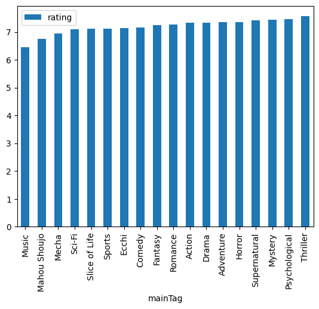

```python
temp[['rating','mainTag']].groupby('mainTag').mean().sort_values('rating').plot(kind='bar',y='rating')
```

## What are the highest Main Tag in Views?

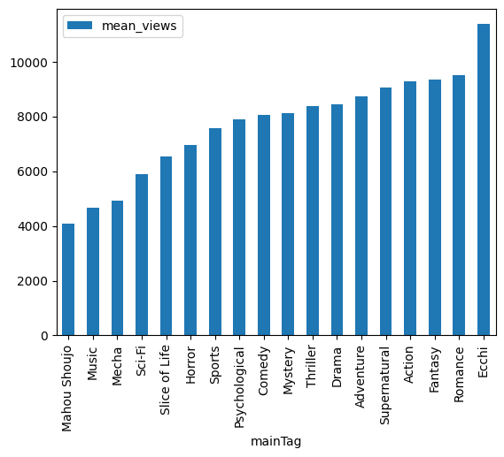

```python
temp[['mean_views','mainTag']].groupby('mainTag').mean().sort_values('mean_views').plot(kind='bar',y='mean_views')
```

Eacchi attract most views

## What are the highest Main Tag in engagment?

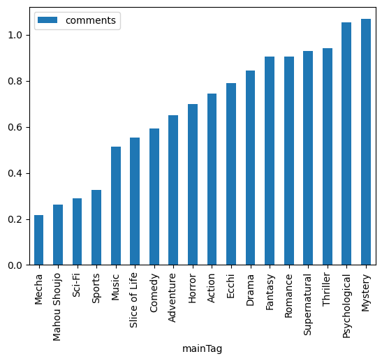

```python
temp[['comments','mainTag']].groupby('mainTag').mean().sort_values('comments').plot(kind='bar',y='comments')
```

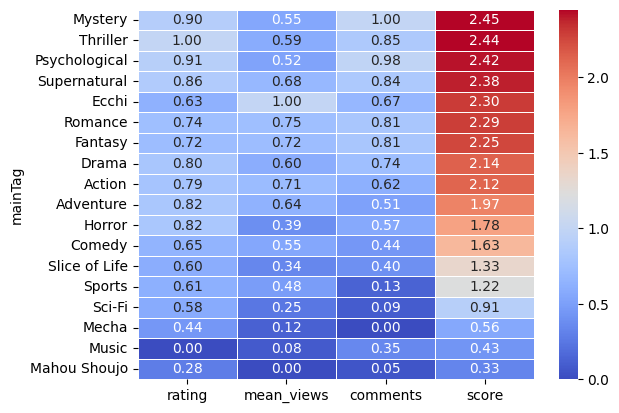

```python
scaler = MinMaxScaler()
standardized_temp = scaler.fit_transform(temp.groupby('mainTag').mean())
stand_df = pd.DataFrame(standardized_temp,index=temp.groupby('mainTag').mean().index,columns=temp.groupby('mainTag').mean().columns)
stand_df['score']=stand_df.sum(axis=1)
sns.heatmap(stand_df.groupby('mainTag').mean().sort_values('score',ascending=False),annot=True, cmap='coolwarm', linewidths=0.5, fmt='.2f')
```

**Overview**: This category stands out due to its high ratings and engagement levels.

- **Ratings**: Psychological content is rated exceptionally high, indicating strong audience approval and quality.
- **Engagement**: Engagement metrics (such as comments, likes, and shares) are notably high, suggesting that viewers are highly interactive with this genre.
- **Views**: Despite its strong performance in ratings and engagement, the Psychological category has average viewership. This indicates a niche but dedicated audience.

### 2. Thriller

**Overview**: The Thriller category excels in ratings and engagement, although its viewership is average.

- **Ratings**: Thriller content receives the highest ratings among all categories, reflecting its strong appeal and quality.
- **Engagement**: Engagement levels are also high, showing that viewers find this genre compelling and are likely to interact with the content.
- **Views**: Like Psychological, the Thriller category has average viewership. This suggests that while the content is highly rated and engaging, it does not attract a significantly larger audience compared to other genres.

### 3. High Ratings and Engagement with Above Average Views

**Overview**: This category performs well across multiple metrics, including ratings, engagement, and viewership.

- **Ratings**: Content in this category is rated highly, demonstrating a high level of quality and audience satisfaction.
- **Engagement**: It also sees strong engagement, with viewers actively interacting with the content.
- **Views**: Additionally, this category has above-average viewership, indicating that it attracts a larger audience while maintaining high engagement and ratings.

## Do rating effect views in arab content?

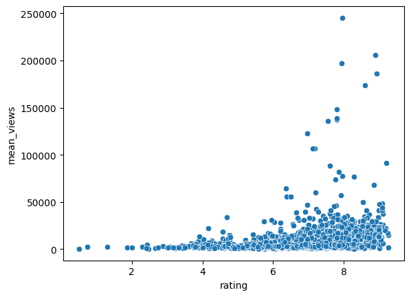

```python
sns.scatterplot(x='rating',y='mean_views',data=df)
```

```python
temp = temp_df.explode('plotTag')[['rating','mean_views','comments','plotTag']]
temp
```

|  | rating | mean_views | comments | plotTag |
| --- | --- | --- | --- | --- |
| 2 | 6.20 | 21450.000000 | 0.0 | Classic Literature |
| 2 | 6.20 | 21450.000000 | 0.0 | School Club |
| 2 | 6.20 | 21450.000000 | 0.0 | Coming of Age |
| 2 | 6.20 | 21450.000000 | 0.0 | School |
| 2 | 6.20 | 21450.000000 | 0.0 | Male Protagonist |
| ... | ... | ... | ... | ... |
| 3962 | 7.49 | 3397.333333 | 0.0 | Space |
| 3962 | 7.49 | 3397.333333 | 0.0 | Police |
| 3962 | 7.49 | 3397.333333 | 0.0 | Shounen |
| 3962 | 7.49 | 3397.333333 | 0.0 | Aliens |
| 3962 | 7.49 | 3397.333333 | 0.0 | Male Protagonist |

42583 rows × 4 columns

## What are the highest Plot Tag in ratings

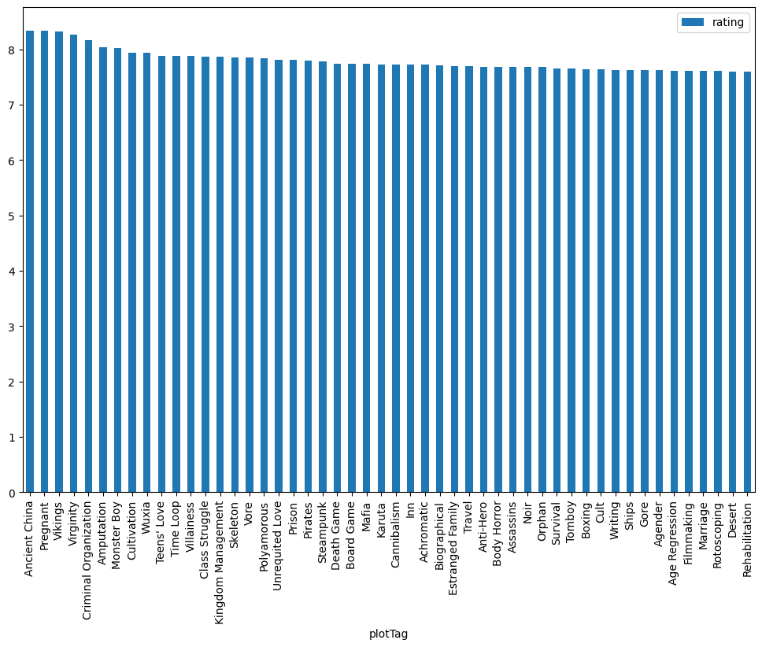

```python
temp[['rating','plotTag']].groupby('plotTag').mean().sort_values('rating',ascending=False).head(50).plot(kind='bar',y='rating',figsize=(12,8))
```

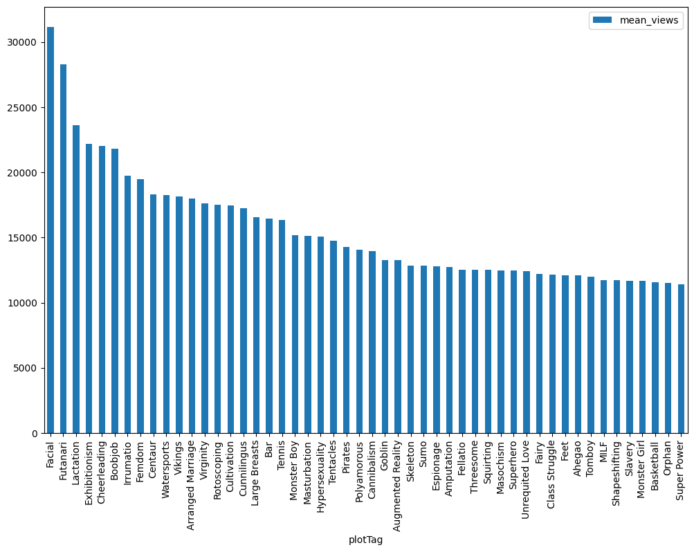

```python
temp[['mean_views','plotTag']].groupby('plotTag').mean().sort_values('mean_views',ascending=False).head(50).plot(kind='bar',y='mean_views',figsize=(12,8))
```

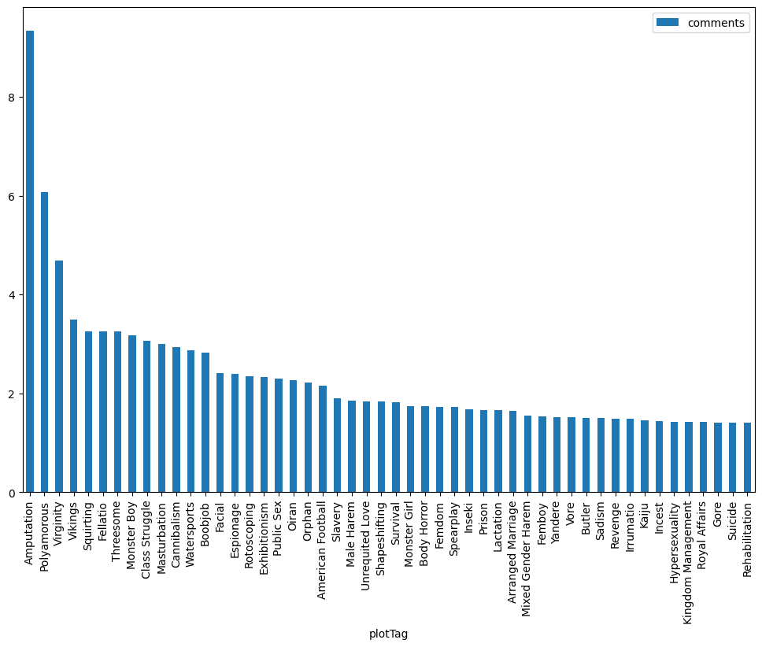

```python
temp[['comments','plotTag']].groupby('plotTag').mean().sort_values('comments',ascending=False).head(50).plot(kind='bar',y='comments',figsize=(12,8))
```

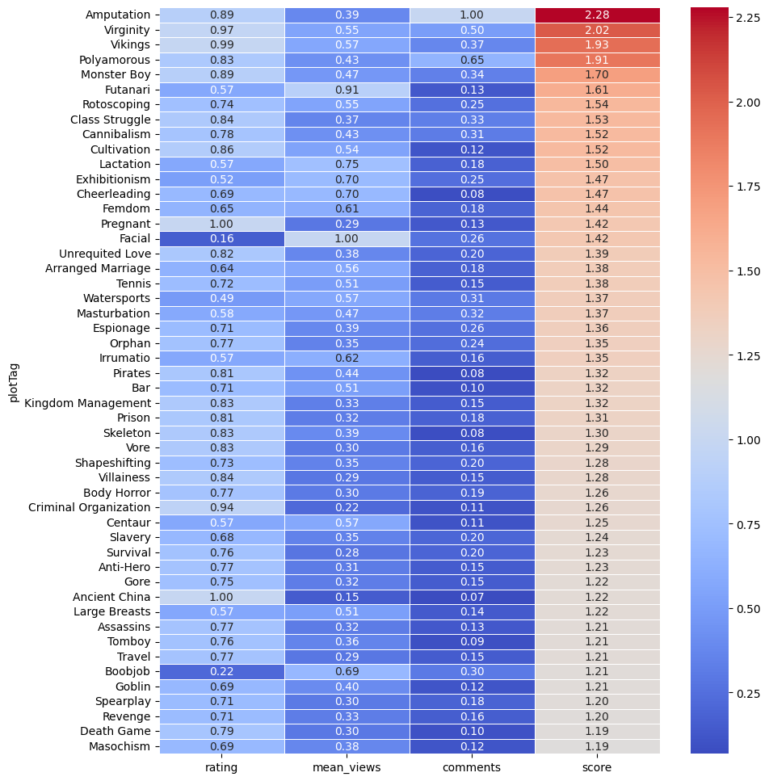

```python
scaler = MinMaxScaler()
standardized_temp = scaler.fit_transform(temp.groupby('plotTag').mean())
stand_df = pd.DataFrame(standardized_temp,index=temp.groupby('plotTag').mean().index,columns=temp.groupby('plotTag').mean().columns)
stand_df['score']=stand_df.sum(axis=1)
plt.figure(figsize=(10,12))
sns.heatmap(stand_df.groupby('plotTag').mean().sort_values('score',ascending=False).head(50),annot=True, cmap='coolwarm', linewidths=0.5, fmt='.2f')
```

## Top 4 Plot Tags

**Note**: Adult tags generally perform well in terms of views, which is expected given that "Etchi" is the highest main tag in views.

### 1. Amputation

- **Ratings**: Very high
- **Engagement**: High
- **Views**: Below average
- **Overview**: The Amputation tag is highly rated and engages viewers effectively. However, its viewership is below average, indicating a niche but passionate audience.

### 2. Virginity

- **Ratings**: High
- **Engagement**: Average
- **Views**: Average
- **Overview**: The Virginity tag achieves high ratings and maintains average levels of engagement and viewership. It strikes a balance between quality and audience reach.

### 3. Vikings

- **Ratings**: High
- **Engagement**: Low
- **Views**: Average
- **Overview**: Content tagged with Vikings enjoys high ratings but struggles with low engagement. Viewership is average, suggesting that while the content is well-received, it does not significantly interact with its audience.

### 4. Polyamorous

- **Ratings**: High
- **Engagement**: Above average
- **Views**: Below average
- **Overview**: The Polyamorous tag has high ratings and above-average engagement. However, its viewership is below average, reflecting a specialized interest within a smaller audience.

### Summary

These top plot tags show varied performance across ratings, engagement, and views. "Amputation" and "Polyamorous" tags excel in ratings and engagement but have lower viewership. The "Virginity" tag maintains high ratings with balanced engagement and views. "Vikings" has high ratings but low engagement, with average viewership. This analysis highlights the diverse appeal and audience interaction of different plot tags.

## Compare global rating to local ratings

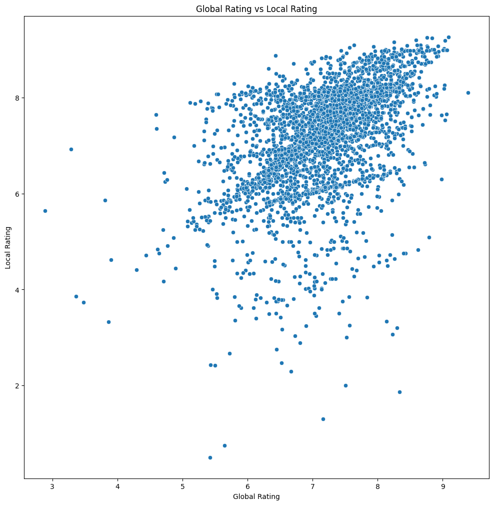

```python
plt.figure(figsize=(12,12))
sns.scatterplot(x='Score',y='rating',data=df)
plt.xlabel('Global Rating')
plt.ylabel('Local Rating')
plt.title('Global Rating vs Local Rating')
plt.show()
```

In general they show corolation but not all the time

Top anime?

```python
# Initialize the MinMaxScaler
scaler = MinMaxScaler()

# Scale the relevant columns
df[['rating_scaled', 'comments_scaled', 'mean_views_scaled']] = scaler.fit_transform(df[['rating', 'comments', 'mean_views']])

# Compute the sum of the scaled columns
df['Arabic_scoring'] = df['rating_scaled'] + df['comments_scaled'] + df['mean_views_scaled']
```

```python
df[['name_x','Arabic_scoring']].sort_values('Arabic_scoring',ascending=False).head(10)
```

|  | name_x | Arabic_scoring |
| --- | --- | --- |
| 1828 | Kimetsu no Yaiba Movie: Mugen Ressha-hen | 2.319310 |
| 3219 | Shingeki no Kyojin: The Final Season Part 2 | 1.993376 |
| 1835 | Kimi ni Todoke 2nd Season | 1.889860 |
| 1968 | Kuroko no Basket 3rd Season | 1.821617 |
| 402 | Boku no Hero Academia 2nd Season | 1.819833 |
| 1831 | Kimetsu no Yaiba: Yuukaku-hen | 1.756096 |
| 3953 | Zutto Mae kara Suki deshita.: Kokuhaku Jikkou ... | 1.674639 |
| 2456 | Nanatsu no Taizai: Imashime no Fukkatsu | 1.655202 |
| 3347 | Spy x Family | 1.564604 |
| 1638 | Jujutsu Kaisen 0 Movie | 1.534385 |

```python
df['Popularity'] = df['Popularity'].str.replace(r'^#', '', regex=True).astype(float)
df['Ranked'] = df['Ranked'].str.replace(r'^#', '', regex=True).astype(float)
```

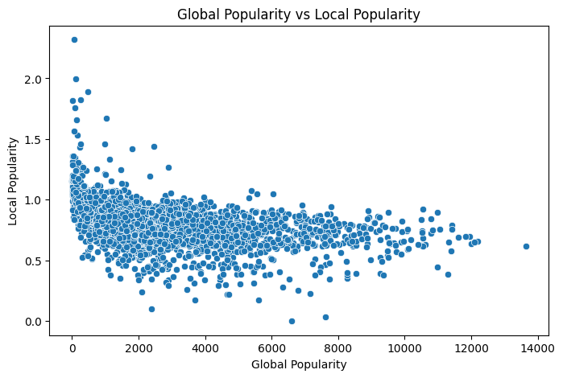

```python
plt.figure(figsize=(8,5))
sns.scatterplot(x='Popularity',y='Arabic_scoring',data=df)
plt.xlabel('Global Popularity')
plt.ylabel('Local Popularity')
plt.title('Global Popularity vs Local Popularity')
plt.show()
```

Popularity is inversely related: lower numbers indicate higher popularity for global scoring according to MyAnimeList, whereas higher numbers indicate better popularity in my scoring system. Consequently, there is generally a weak correlation between the two metrics.

```python
df.sort_values('Arabic_scoring',ascending=False).to_csv('Anime_data.csv',index=False)
```